# MSCA 31008 HW1

Ruoxin Shi

2022/1/19

## Load Data

Load data from the library. Since the column ‘Class’ is categorical, in order to get a linear regression model, we create dummy variables for ‘Class’: ‘class_good’ and ‘class_bad’.

```r
# load data
library(caret)
data(GermanCredit)

# create dummy variables for 'Class'
GermanCredit$class_good <- ifelse(GermanCredit$Class == 'Good', 1, 0)
GermanCredit$class_bad <- ifelse(GermanCredit$Class == 'Bad', 1, 0)
GermanCredit <- subset(GermanCredit, select = -c(Class))
```

## Create Full Model

First, we use all the variables to create a full model.

```r
full_model <- lm(Amount ~ ., data = GermanCredit)
summary(full_model)
```

```
##
## Call:
## lm(formula = Amount ~ ., data = GermanCredit)
##
## Residuals:
##     Min      1Q  Median      3Q     Max
## -5339.1 -1033.7  -159.7   729.6 10992.7
##
## Coefficients: (14 not defined because of singularities)
##                                         Estimate Std. Error t value Pr(>|t|)
## (Intercept)                             7074.535    935.833   7.560 9.50e-14 ***
## Duration                                 124.633      5.489  22.705  < 2e-16 ***
## InstallmentRatePercentage               -794.600     54.727 -14.519  < 2e-16 ***
## ResidenceDuration                        -51.540     59.983  -0.859 0.390429
## Age                                        6.355      6.091   1.043 0.297015
## NumberExistingCredits                     60.757    127.081   0.478 0.632690
## NumberPeopleMaintenance                 -209.321    172.372  -1.214 0.224914
## Telephone                               -496.498    133.541  -3.718 0.000213 ***
## ForeignWorker                           -302.061    320.233  -0.943 0.345790
## CheckingAccountStatus.lt.0              -203.329    161.198  -1.261 0.207486
## CheckingAccountStatus.0.to.200           141.097    155.264   0.909 0.363708
## CheckingAccountStatus.gt.200            -641.467    252.161  -2.544 0.011120 *
## CheckingAccountStatus.none                    NA         NA      NA       NA
## CreditHistory.NoCredit.AllPaid           757.073    326.607   2.318 0.020661 *
## CreditHistory.ThisBank.AllPaid          -148.837    316.975  -0.470 0.638782
## CreditHistory.PaidDuly                   -58.534    166.372  -0.352 0.725045
## CreditHistory.Delay                       76.062    231.960   0.328 0.743052
## CreditHistory.Critical                        NA         NA      NA       NA
## Purpose.NewCar                         -1837.994    566.614  -3.244 0.001220 **
## Purpose.UsedCar                        -1118.764    578.239  -1.935 0.053314 .
## Purpose.Furniture.Equipment            -1869.154    573.097  -3.261 0.001148 **
## Purpose.Radio.Television               -2100.813    569.549  -3.689 0.000238 ***
## Purpose.DomesticAppliance              -2511.654    775.226  -3.240 0.001237 **
## Purpose.Repairs                        -1774.109    682.596  -2.599 0.009493 **
## Purpose.Education                      -1980.284    616.027  -3.215 0.001350 **
## Purpose.Vacation                              NA         NA      NA       NA
## Purpose.Retraining                     -2193.130    836.357  -2.622 0.008875 **
## Purpose.Business                       -2025.211    581.722  -3.481 0.000521 ***
## Purpose.Other                                 NA         NA      NA       NA
## SavingsAccountBonds.lt.100              -371.033    162.386  -2.285 0.022539 *
```

[output cut: 24 more lines]

```
## Housing.Rent                             197.975    327.442   0.605 0.545582
## Housing.Own                              112.772    312.165   0.361 0.717988
## Housing.ForFree                               NA         NA      NA       NA
## Job.UnemployedUnskilled                -1677.614    460.708  -3.641 0.000286 ***
## Job.UnskilledResident                  -1192.269    241.069  -4.946 8.96e-07 ***
## Job.SkilledEmployee                    -1251.295    195.112  -6.413 2.24e-10 ***
## Job.Management.SelfEmp.HighlyQualified        NA         NA      NA       NA
## class_good                              -369.922    146.495  -2.525 0.011726 *
## class_bad                                     NA         NA      NA       NA
## ---
## Signif. codes:  0 '***' 0.001 '**' 0.01 '*' 0.05 '.' 0.1 ' ' 1
##
## Residual standard error: 1806 on 951 degrees of freedom
## Multiple R-squared:  0.6105, Adjusted R-squared:  0.5909
## F-statistic: 31.06 on 48 and 951 DF,  p-value: < 2.2e-16
```

## Feature Selection

According to the above summary, we remove variables with NA as coefficient estimation.

```r
cleaned_df <- subset(GermanCredit, select = -c(CheckingAccountStatus.none, CreditHistory.Critical,
                                    Purpose.Vacation, Purpose.Other, SavingsAccountBonds.Unknown,
                                    EmploymentDuration.Unemployed, Personal.Male.Married.Widowed,
                                    Personal.Female.Single, OtherDebtorsGuarantors.Guarantor, Property.Unknown,
                                    OtherInstallmentPlans.None, Housing.ForFree, Job.Management.SelfEmp.HighlyQualified,
                                    class_bad))
```

## Split Data and Create Repetition Models

```r
# create single model use cleaned data
model2 <- lm(Amount ~ ., data = cleaned_df)
summary(model2)
```

```
##
## Call:
## lm(formula = Amount ~ ., data = cleaned_df)
##
## Residuals:
##     Min      1Q  Median      3Q     Max
## -5339.1 -1033.7  -159.7   729.6 10992.7
##
## Coefficients:
##                                     Estimate Std. Error t value Pr(>|t|)
## (Intercept)                         7074.535    935.833   7.560 9.50e-14 ***
## Duration                             124.633      5.489  22.705  < 2e-16 ***
## InstallmentRatePercentage           -794.600     54.727 -14.519  < 2e-16 ***
## ResidenceDuration                    -51.540     59.983  -0.859 0.390429
## Age                                    6.355      6.091   1.043 0.297015
## NumberExistingCredits                 60.757    127.081   0.478 0.632690
## NumberPeopleMaintenance             -209.321    172.372  -1.214 0.224914
## Telephone                           -496.498    133.541  -3.718 0.000213 ***
## ForeignWorker                       -302.061    320.233  -0.943 0.345790
## CheckingAccountStatus.lt.0          -203.329    161.198  -1.261 0.207486
## CheckingAccountStatus.0.to.200       141.097    155.264   0.909 0.363708
## CheckingAccountStatus.gt.200        -641.467    252.161  -2.544 0.011120 *
## CreditHistory.NoCredit.AllPaid       757.073    326.607   2.318 0.020661 *
## CreditHistory.ThisBank.AllPaid      -148.837    316.975  -0.470 0.638782
## CreditHistory.PaidDuly               -58.534    166.372  -0.352 0.725045
## CreditHistory.Delay                   76.062    231.960   0.328 0.743052
## Purpose.NewCar                     -1837.994    566.614  -3.244 0.001220 **
## Purpose.UsedCar                    -1118.764    578.239  -1.935 0.053314 .
## Purpose.Furniture.Equipment        -1869.154    573.097  -3.261 0.001148 **
## Purpose.Radio.Television           -2100.813    569.549  -3.689 0.000238 ***
## Purpose.DomesticAppliance          -2511.654    775.226  -3.240 0.001237 **
## Purpose.Repairs                    -1774.109    682.596  -2.599 0.009493 **
## Purpose.Education                  -1980.284    616.027  -3.215 0.001350 **
## Purpose.Retraining                 -2193.130    836.357  -2.622 0.008875 **
## Purpose.Business                   -2025.211    581.722  -3.481 0.000521 ***
## SavingsAccountBonds.lt.100          -371.033    162.386  -2.285 0.022539 *
## SavingsAccountBonds.100.to.500      -592.694    229.764  -2.580 0.010041 *
## SavingsAccountBonds.500.to.1000     -655.489    268.547  -2.441 0.014833 *
## SavingsAccountBonds.gt.1000         -374.993    299.480  -1.252 0.210824
## EmploymentDuration.lt.1              117.325    314.661   0.373 0.709335
```

[output cut: 10 more lines]

```
## Property.CarOther                   -534.049    275.304  -1.940 0.052693 .
## OtherInstallmentPlans.Bank          -173.259    177.165  -0.978 0.328349
## OtherInstallmentPlans.Stores         -92.480    282.617  -0.327 0.743569
## Housing.Rent                         197.975    327.442   0.605 0.545582
## Housing.Own                          112.772    312.165   0.361 0.717988
## Job.UnemployedUnskilled            -1677.614    460.708  -3.641 0.000286 ***
## Job.UnskilledResident              -1192.269    241.069  -4.946 8.96e-07 ***
## Job.SkilledEmployee                -1251.295    195.112  -6.413 2.24e-10 ***
## class_good                          -369.922    146.495  -2.525 0.011726 *
## ---
## Signif. codes:  0 '***' 0.001 '**' 0.01 '*' 0.05 '.' 0.1 ' ' 1
##
## Residual standard error: 1806 on 951 degrees of freedom
## Multiple R-squared:  0.6105, Adjusted R-squared:  0.5909
## F-statistic: 31.06 on 48 and 951 DF,  p-value: < 2.2e-16
```

```r
#create dataframe to store model coefficients
coeffs <- data.frame(matrix(ncol = 49, nrow = 1000))
colnames(coeffs) <- names(model2$coefficients)

#create dataframe to store model coefficients
r_square <- data.frame(matrix(ncol = 3, nrow = 1000))
colnames(r_square) <- c("R^2 for Train", "R^2 for Test", "Percent Drop")
```

```r
n <- 1000

for (i in 1:n) {
  # split
  train_ind <- sample(seq_len(nrow(cleaned_df)), size = 632)
  train <- cleaned_df[train_ind, ]
  test <- cleaned_df[-train_ind, ]

  test_no_amount <- subset(test, select = -c(Amount))

  m <- lm(Amount ~ ., data = train)
  res <- summary(m)
  r_square[i,1] <- res$r.squared
  coeffs[i,] <- m$coefficients
  pred <- predict(m, test_no_amount)
  cor_coeff <- cor(test$Amount, pred)^2
  r_square[i,2] <- cor_coeff
}
```

## Plot Histograms of Coefficients and R^2

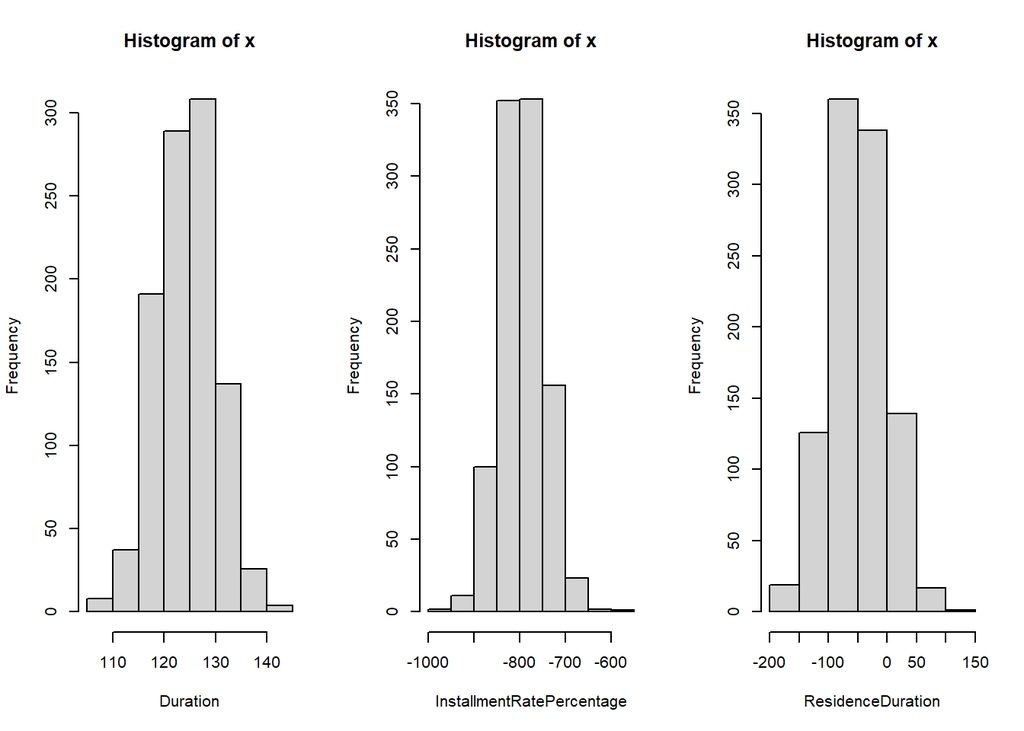

```r
# Plot histogram of 3 coefficients
par(mfrow = c(1, 3))
for (i in 2:4){
  x <- coeffs[,i]
  hist(x, xlab=colnames(coeffs)[i])
}
```

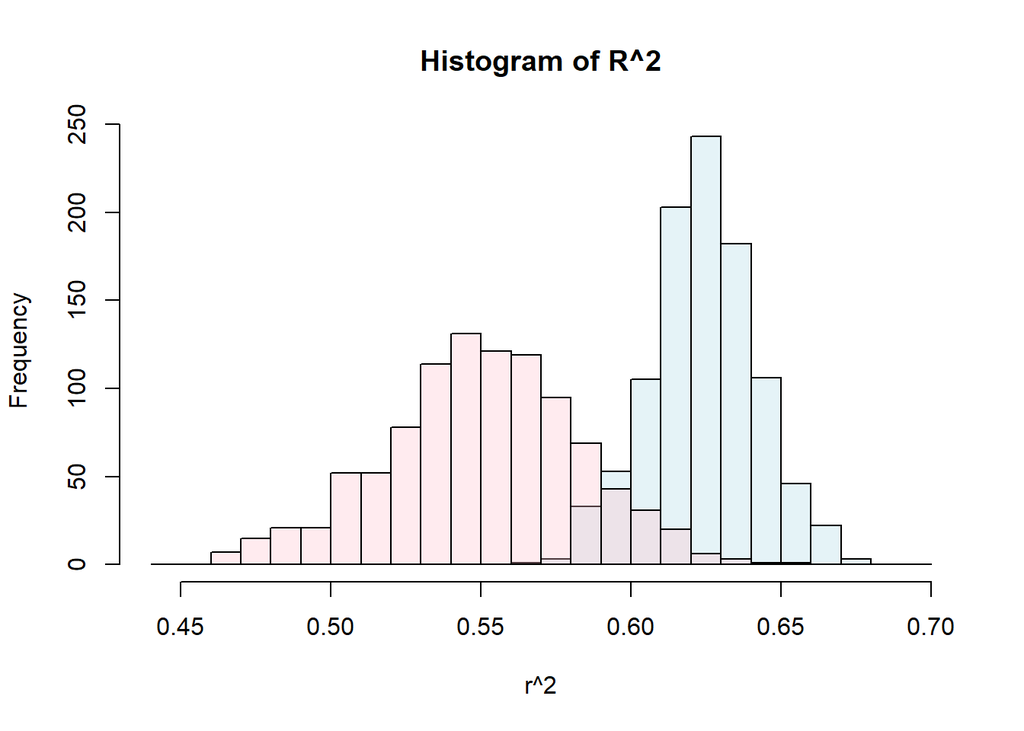

```r
# Plot distribution of R squared in train/ hold out
b <- min(c(r_square[,1], r_square[, 2])) # Set the minimum for the breakpoints
e <- max(c(r_square[,1], r_square[, 2])) # Set the maximum for the breakpoints
ax <- seq(round(b,2)-0.02,round(e,2)+0.02, by = 0.01) # Make a neat vector for the breakpoints

c1 <- rgb(173,216,230,max = 255, alpha = 80, names = "lt.blue")
c2 <- rgb(255,192,203, max = 255, alpha = 80, names = "lt.pink")

hgA <- hist(r_square[,1], breaks = ax, plot = FALSE) # Save first histogram data
hgB <- hist(r_square[,2], breaks = ax, plot = FALSE) # Save 2nd histogram data

plot(hgA, col = c1, main="Histogram of R^2", xlab = "r^2") # Plot 1st histogram using a transparent color
plot(hgB, col = c2, add = TRUE) # Add 2nd histogram using different color
```

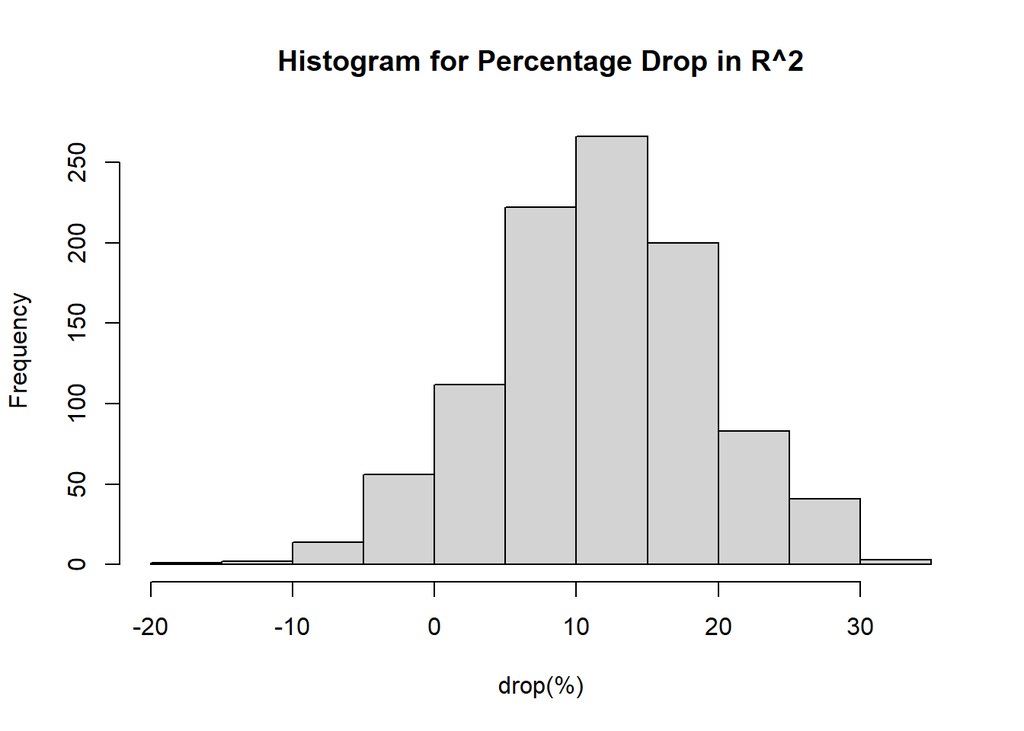

```r
par(mfrow = c(1, 1))
# Calculate percentage decrease of R square from train to holdout and
# plot the distribution
Train.R.Squared <- r_square[, 1]
Holdout.R.Squared <- r_square[, 2]
r_square[, 3] <- (Train.R.Squared - Holdout.R.Squared)/Train.R.Squared*100
hist(r_square[, 3], xlab="drop(%)", main="Histogram for Percentage Drop in R^2")
```

**Interpret the results of the above plots? How would we hope/expect them to look? Does this indicate a good result? What do these plots say about what we usually expect the R squared to be and how much R squared we usually expect to lose from Train to holdout?**  
From the above plots we could see that the shape of these 2 histogram is close to a normal distribution. This indicate a relatively good result. Also, the mean value of R^2 for trained data is about 0.63 while that of test data is about 0.55. And there is a drop of 10-15% in average in the R^2 and most of the R^2 are dropped from train to test data. Thus, we would expect R^2 to be about 0.63 and there would be a 10-15% loss from train to holdout.  
One explanation for this drop might be that the model has a relatively low generalization. It has too many variables. It might work fine with the train data (since the model is built based on these), but might fail to fit well for the holdout data.

## Calculate Mean, Stdev of Repetition Model & Make Comparison

```r
# Compute the averages of all 1000 coefficients.
# Compute the standard deviation of all 1000 coefficients (for each beta)
coeff_data <- data.frame(matrix(ncol = 49, nrow = 4))
colnames(coeff_data) <- names(model2$coefficients)
rownames(coeff_data) <- c("mean", "stdev", "coeff_full", "Percent Diff")
for (i in 1:49) {
  coeff_data[1, i] <- mean(coeffs[,i])
  coeff_data[2, i] <- sd(coeffs[,i])
}

# Compare average across 1000 to single model built using entire sample.
coeff_data[3, ] <- na.omit(full_model$coefficients)[1:49]

# Compare the means of the 1000 coefficients to the coefficients from the model
# created in step 2 created using the entire sample.
# Show the percentage difference
coeff_data[4,] <- (abs(coeff_data[1, ] - coeff_data[3, ]) / ((coeff_data[1, ] + coeff_data[3,]) / 2)) * 100
#coeff_data[4,] <- (coeff_data[1, ] - coeff_data[3, ]) / coeff_data[1, ]*100

# Transpose
coeff_data_transpose <- as.data.frame(t(as.matrix(coeff_data)))
```

```r
knitr::kable(coeff_data_transpose)
```

|  | mean | stdev | coeff_full | Percent Diff |
| --- | --- | --- | --- | --- |
| (Intercept) | 7049.248045 | 1286.904322 | 7074.534699 | 0.3580720 |
| Duration | 124.469701 | 5.738557 | 124.633077 | 0.1311712 |
| InstallmentRatePercentage | -794.409349 | 48.118965 | -794.599858 | -0.0239784 |
| ResidenceDuration | -50.173995 | 47.241535 | -51.539571 | -2.6851385 |
| Age | 6.021415 | 5.447922 | 6.355093 | 5.3921099 |
| NumberExistingCredits | 63.898725 | 100.794363 | 60.757175 | 5.0403549 |
| NumberPeopleMaintenance | -216.271028 | 130.073262 | -209.320752 | -3.2661699 |
| Telephone | -491.415908 | 113.988310 | -496.497775 | -1.0288079 |
| ForeignWorker | -287.619970 | 247.562142 | -302.060945 | -4.8978947 |
| CheckingAccountStatus.lt.0 | -197.411222 | 127.957266 | -203.329414 | -2.9536269 |
| CheckingAccountStatus.0.to.200 | 139.462845 | 118.625618 | 141.097435 | 1.1652327 |
| CheckingAccountStatus.gt.200 | -633.890837 | 143.095439 | -641.467097 | -1.1880993 |
| CreditHistory.NoCredit.AllPaid | 740.787854 | 317.720055 | 757.072851 | 2.1744341 |
| CreditHistory.ThisBank.AllPaid | -153.466747 | 266.341905 | -148.836825 | -3.0630948 |
| CreditHistory.PaidDuly | -58.350174 | 125.699143 | -58.534388 | -0.3152053 |
| CreditHistory.Delay | 78.154909 | 211.485445 | 76.061823 | 2.7144729 |
| Purpose.NewCar | -1811.234394 | 1091.071625 | -1837.994137 | -1.4665973 |
| Purpose.UsedCar | -1089.655653 | 1089.985993 | -1118.764346 | -2.6361555 |
| Purpose.Furniture.Equipment | -1837.968574 | 1084.692253 | -1869.154196 | -1.6824704 |
| Purpose.Radio.Television | -2070.361395 | 1085.691233 | -2100.813032 | -1.4600990 |
| Purpose.DomesticAppliance | -2490.169829 | 1130.862848 | -2511.654326 | -0.8590664 |
| Purpose.Repairs | -1749.629961 | 1124.467542 | -1774.108505 | -1.3893508 |
| Purpose.Education | -1948.987660 | 1086.884461 | -1980.283937 | -1.5929811 |
| Purpose.Retraining | -2178.093172 | 1217.187819 | -2193.129750 | -0.6879804 |
| Purpose.Business | -1997.331991 | 1101.176853 | -2025.210517 | -1.3861147 |
| SavingsAccountBonds.lt.100 | -373.786548 | 143.088126 | -371.033108 | -0.7393575 |
| SavingsAccountBonds.100.to.500 | -598.102629 | 181.082131 | -592.693869 | -0.9084273 |
| SavingsAccountBonds.500.to.1000 | -659.229820 | 199.182174 | -655.488989 | -0.5690694 |
| SavingsAccountBonds.gt.1000 | -381.057910 | 191.467660 | -374.992647 | -1.6044596 |
| EmploymentDuration.lt.1 | 107.691441 | 315.945180 | 117.324800 | 8.5623679 |
| EmploymentDuration.1.to.4 | 58.355138 | 311.715589 | 63.304244 | 8.1360034 |
| EmploymentDuration.4.to.7 | 151.193526 | 322.664525 | 157.356477 | 3.9947822 |
| EmploymentDuration.gt.7 | -149.433678 | 316.894331 | -142.300409 | -4.8902540 |
| Personal.Male.Divorced.Seperated | 442.672317 | 256.056440 | 446.005892 | 0.7502323 |
| Personal.Female.NotSingle | 267.156893 | 127.690716 | 269.338283 | 0.8132004 |
| Personal.Male.Single | 748.182141 | 140.464328 | 741.920908 | 0.8403759 |
| OtherDebtorsGuarantors.None | 70.140536 | 174.684041 | 76.713816 | 8.9521076 |
| OtherDebtorsGuarantors.CoApplicant | 651.270161 | 307.182204 | 657.805428 | 0.9984553 |
| Property.RealEstate | -789.927423 | 278.461901 | -790.356830 | -0.0543455 |
| Property.Insurance | -553.501547 | 283.418884 | -556.243795 | -0.4942121 |
| Property.CarOther | -531.617930 | 280.843041 | -534.048566 | -0.4561720 |
| OtherInstallmentPlans.Bank | -173.820449 | 151.021179 | -173.258637 | -0.3237373 |
| OtherInstallmentPlans.Stores | -81.570958 | 269.531108 | -92.479606 | -12.5350331 |
| Housing.Rent | 187.563232 | 358.643395 | 197.974563 | 5.4009391 |
| Housing.Own | 104.554894 | 353.307561 | 112.771704 | 7.5617165 |
| Job.UnemployedUnskilled | -1615.731978 | 592.387526 | -1677.614437 | -3.7580291 |
| Job.UnskilledResident | -1183.179766 | 226.288339 | -1192.268605 | -0.7652315 |
| Job.SkilledEmployee | -1243.654754 | 207.053520 | -1251.294559 | -0.6124217 |
| class_good | -364.589487 | 141.232214 | -369.921813 | -1.4519387 |

## Calcualte Confidence Interval

```r
# Sort each coefficient's 1000 values. Compute 2.5%-97.5% Confidence
# Intervals (CI). Scale these CI's down by a factor of .632^0.5 .
CI <- data.frame(matrix(ncol = 7, nrow = 49))
rownames(CI) <- names(model2$coefficients)
colnames(CI) <- c("Rep.lower", "Rep.upper", "Rep scaled width",
                  "Full.lower", "Full.upper", "Full width", "Width Diff")

for (i in 1:49) {
  sample.mean <- coeff_data[1,i]
  sample.se <- coeff_data[2,i]/sqrt(n)

  alpha <- 0.05
  degrees.freedom <- n - 1
  t.score <- qt(p=alpha/2, df=degrees.freedom,lower.tail=F)

  margin.error <- t.score * sample.se
  lower.bound <- sample.mean - margin.error
  upper.bound <- sample.mean + margin.error
  CI[i,1] <- lower.bound
  CI[i,2] <- upper.bound
  CI[i,3] <- (upper.bound - lower.bound)*sqrt(0.632)
}

# confidence interval of full model
interval <- confint(full_model, level=0.95)
interval <- na.omit(interval)
CI[, 4] <- interval[, 1]
CI[, 5] <- interval[, 2]
CI[, 6] <- interval[, 2] - interval[, 1]
CI[, 7] <- CI[,3] - CI[,6]

# check whether rep model has a tighter CI or not
CI$tighter <- ifelse(CI$`Width Diff` < 0, 1, 0)
```

```r
knitr::kable(CI)
```

|  | Rep.lower | Rep.upper | Rep scaled width | Full.lower | Full.upper | Full width | Width Diff | tighter |
| --- | --- | --- | --- | --- | --- | --- | --- | --- |
| (Intercept) | 6969.389602 | 7129.106488 | 126.9724133 | 5237.999120 | 8911.070277 | 3673.07116 | -3546.09874 | 1 |
| Duration | 124.113597 | 124.825806 | 0.5661947 | 113.860629 | 135.405524 | 21.54489 | -20.97870 | 1 |
| InstallmentRatePercentage | -797.395356 | -791.423341 | 4.7476577 | -902.000453 | -687.199264 | 214.80119 | -210.05353 | 1 |
| ResidenceDuration | -53.105554 | -47.242437 | 4.6610860 | -169.254596 | 66.175454 | 235.43005 | -230.76896 | 1 |
| Age | 5.683346 | 6.359484 | 0.5375192 | -5.597443 | 18.307628 | 23.90507 | -23.36755 | 1 |
| NumberExistingCredits | 57.643963 | 70.153488 | 9.9448757 | -188.633886 | 310.148236 | 498.78212 | -488.83725 | 1 |
| NumberPeopleMaintenance | -224.342683 | -208.199372 | 12.8336782 | -547.594555 | 128.953051 | 676.54761 | -663.71393 | 1 |
| Telephone | -498.489417 | -484.342399 | 11.2466565 | -758.566919 | -234.428632 | 524.13829 | -512.89163 | 1 |
| ForeignWorker | -302.982361 | -272.257579 | 24.4257185 | -930.505042 | 326.383152 | 1256.88819 | -1232.46248 | 1 |
| CheckingAccountStatus.lt.0 | -205.351570 | -189.470875 | 12.6249035 | -519.673663 | 113.014835 | 632.68850 | -620.06360 | 1 |
| CheckingAccountStatus.0.to.200 | 132.101570 | 146.824121 | 11.7041964 | -163.602012 | 445.796883 | 609.39890 | -597.69470 | 1 |
| CheckingAccountStatus.gt.200 | -642.770579 | -625.011095 | 14.1185113 | -1136.323438 | -146.610755 | 989.71268 | -975.59417 | 1 |
| CreditHistory.NoCredit.AllPaid | 721.071836 | 760.503873 | 31.3478488 | 116.118732 | 1398.026971 | 1281.90824 | -1250.56039 | 1 |
| CreditHistory.ThisBank.AllPaid | -169.994511 | -136.938984 | 26.2786237 | -770.888427 | 473.214777 | 1244.10320 | -1217.82458 | 1 |
| CreditHistory.PaidDuly | -66.150395 | -50.549954 | 12.4021058 | -385.032655 | 267.963880 | 652.99653 | -640.59443 | 1 |
| CreditHistory.Delay | 65.031246 | 91.278572 | 20.8662112 | -379.150586 | 531.274232 | 910.42482 | -889.55861 | 1 |
| Purpose.NewCar | -1878.940501 | -1743.528287 | 107.6505805 | -2949.952109 | -726.036165 | 2223.91594 | -2116.26536 | 1 |
| Purpose.UsedCar | -1157.294392 | -1022.016915 | 107.5434666 | -2253.536338 | 16.007646 | 2269.54398 | -2162.00052 | 1 |
| Purpose.Furniture.Equipment | -1905.278810 | -1770.658337 | 107.0211598 | -2993.835699 | -744.472693 | 2249.36301 | -2142.34185 | 1 |
| Purpose.Radio.Television | -2137.733623 | -2002.989167 | 107.1197241 | -3218.531733 | -983.094331 | 2235.43740 | -2128.31768 | 1 |
| Purpose.DomesticAppliance | -2560.345168 | -2419.994491 | 111.5765815 | -4033.004932 | -990.303719 | 3042.70121 | -2931.12463 | 1 |
| Purpose.Repairs | -1819.408441 | -1679.851482 | 110.9455886 | -3113.677578 | -434.539432 | 2679.13815 | -2568.19256 | 1 |
| Purpose.Education | -2016.433933 | -1881.541386 | 107.2374539 | -3189.212463 | -771.355410 | 2417.85705 | -2310.61960 | 1 |
| Purpose.Retraining | -2253.625379 | -2102.560964 | 120.0938346 | -3834.448388 | -551.811112 | 3282.63728 | -3162.54344 | 1 |
| Purpose.Business | -2065.665175 | -1928.998808 | 108.6476128 | -3166.818328 | -883.602706 | 2283.21562 | -2174.56801 | 1 |
| SavingsAccountBonds.lt.100 | -382.665837 | -364.907259 | 14.1177898 | -689.709420 | -52.356797 | 637.35262 | -623.23483 | 1 |
| SavingsAccountBonds.100.to.500 | -609.339624 | -586.865634 | 17.8664682 | -1043.595987 | -141.791751 | 901.80424 | -883.93777 | 1 |
| SavingsAccountBonds.500.to.1000 | -671.590008 | -646.869633 | 19.6523089 | -1182.501512 | -128.476466 | 1054.02505 | -1034.37274 | 1 |
| SavingsAccountBonds.gt.1000 | -392.939375 | -369.176445 | 18.8911564 | -962.709732 | 212.724438 | 1175.43417 | -1156.54301 | 1 |
| EmploymentDuration.lt.1 | 88.085562 | 127.297320 | 31.1727307 | -500.185674 | 734.835275 | 1235.02095 | -1203.84822 | 1 |
| EmploymentDuration.1.to.4 | 39.011725 | 77.698551 | 30.7554182 | -527.064140 | 653.672628 | 1180.73677 | -1149.98135 | 1 |
| EmploymentDuration.4.to.7 | 131.170681 | 171.216372 | 31.8356950 | -460.692407 | 775.405360 | 1236.09777 | -1204.26207 | 1 |
| EmploymentDuration.gt.7 | -169.098456 | -129.768900 | 31.2663788 | -731.071522 | 446.470705 | 1177.54223 | -1146.27585 | 1 |
| Personal.Male.Divorced.Seperated | 426.782815 | 458.561818 | 25.2638083 | -204.625899 | 1096.637683 | 1301.26358 | -1275.99977 | 1 |
| Personal.Female.NotSingle | 259.233086 | 275.080700 | 12.5986044 | -166.111114 | 704.787681 | 870.89879 | -858.30019 | 1 |
| Personal.Male.Single | 739.465671 | 756.898611 | 13.8589127 | 311.156994 | 1172.684821 | 861.52783 | -847.66891 | 1 |
| OtherDebtorsGuarantors.None | 59.300573 | 80.980499 | 17.2352007 | -464.237940 | 617.665572 | 1081.90351 | -1064.66831 | 1 |
| OtherDebtorsGuarantors.CoApplicant | 632.208066 | 670.332256 | 30.3081317 | -114.538295 | 1430.149151 | 1544.68745 | -1514.37931 | 1 |
| Property.RealEstate | -807.207289 | -772.647557 | 27.4744431 | -1354.030022 | -226.683638 | 1127.34638 | -1099.87194 | 1 |
| Property.Insurance | -571.089017 | -535.914077 | 27.9635239 | -1111.786719 | -0.700871 | 1111.08585 | -1083.12232 | 1 |
| Property.CarOther | -549.045557 | -514.190304 | 27.7093783 | -1074.321359 | 6.224226 | 1080.54558 | -1052.83621 | 1 |
| OtherInstallmentPlans.Bank | -183.192021 | -164.448877 | 14.9005044 | -520.938988 | 174.421714 | 695.36070 | -680.46020 | 1 |
| OtherInstallmentPlans.Stores | -98.296626 | -64.845290 | 26.5932864 | -647.103885 | 462.144673 | 1109.24856 | -1082.65527 | 1 |
| Housing.Rent | 165.307729 | 209.818736 | 35.3855502 | -444.616967 | 840.566094 | 1285.18306 | -1249.79751 | 1 |
| Housing.Own | 82.630504 | 126.479283 | 34.8590900 | -499.839748 | 725.383156 | 1225.22290 | -1190.36381 | 1 |
| Job.UnemployedUnskilled | -1652.492400 | -1578.971556 | 58.4479145 | -2581.735908 | -773.492966 | 1808.24294 | -1749.79503 | 1 |
| Job.UnskilledResident | -1197.222018 | -1169.137514 | 22.3267387 | -1665.357498 | -719.179713 | 946.17778 | -923.85105 | 1 |
| Job.SkilledEmployee | -1256.503395 | -1230.806113 | 20.4289353 | -1634.194222 | -868.394895 | 765.79933 | -745.37039 | 1 |
| class_good | -373.353607 | -355.825366 | 13.9346762 | -657.412181 | -82.431445 | 574.98074 | -561.04606 | 1 |

## Interpret Result

**How did the means compare?**  
For most of the coefficients, the difference in mean is under 5%. This means that the sample mean for coefficients are close to the full model’s coefficient value.  
Some of the coefficients have higher difference, but no greater than 13%:

```r
coeff_data_transpose[abs(coeff_data_transpose$`Percent Diff`) >= 5,]
```

```
##                                    mean      stdev coeff_full Percent Diff
## Age                            6.021415   5.447922   6.355093     5.392110
## NumberExistingCredits         63.898725 100.794363  60.757175     5.040355
## EmploymentDuration.lt.1      107.691441 315.945180 117.324800     8.562368
## EmploymentDuration.1.to.4     58.355138 311.715589  63.304244     8.136003
## OtherDebtorsGuarantors.None   70.140536 174.684041  76.713816     8.952108
## OtherInstallmentPlans.Stores -81.570958 269.531108 -92.479606   -12.535033
## Housing.Rent                 187.563232 358.643396 197.974563     5.400939
## Housing.Own                  104.554893 353.307561 112.771704     7.561717
```

**How about the confidence intervals, how many were tighter or broader?**  
Confidence intervals for all the coefficients are tighter for the Repetition model than those of the full model.  
**What does this say about each method? What if we tried doing 10,000 samples?**  
A tighter confidence interval means a smaller margin of error. Thus we could have a more precise estimate of the parameters. If we do 10000 samples, we would have even narrower confidence intervals. Larger sample size would give us more precise estimates (and hence have narrower confidence intervals) than smaller ones.